# Some Common Distributions

Statistical Inference

Brian Caffo, Jeff Leek, Roger Peng

## The Bernoulli distribution

- The **Bernoulli distribution** arises as the result of a binary outcome
- Bernoulli random variables take (only) the values 1 and 0 with probabilities of (say) $p$ and $1-p$ respectively
- The PMF for a Bernoulli random variable $X$ is $P(X = x) = p^x (1 - p)^{1 - x}$
- The mean of a Bernoulli random variable is $p$ and the variance is $p(1 - p)$
- If we let $X$ be a Bernoulli random variable, it is typical to call $X=1$ as a “success” and $X=0$ as a “failure”

## Binomial trials

- The *binomial random variables* are obtained as the sum of iid Bernoulli trials
- In specific, let $X_1,\ldots,X_n$ be iid Bernoulli$(p)$; then $X = \sum_{i=1}^n X_i$ is a binomial random variable
- The binomial mass function is $P(X = x) = \left( \begin{array}{c} n \\ x \end{array} \right) p^x(1 - p)^{n-x}$ for $x=0,\ldots,n$

## Choose

- Recall that the notation $\left( \begin{array}{c} n \\ x \end{array} \right) = \frac{n!}{x!(n-x)!}$ (read “$n$ choose $x$”) counts the number of ways of selecting $x$ items out of $n$ without replacement disregarding the order of the items

$\left( \begin{array}{c} n \\ 0 \end{array} \right) = \left( \begin{array}{c} n \\ n \end{array} \right) = 1$

## Example

```r
choose(8, 7) * .5 ^ 8 + choose(8, 8) * .5 ^ 8
```

```
## [1] 0.03515625
```

```r
pbinom(6, size = 8, prob = .5, lower.tail = FALSE)
```

```
## [1] 0.03515625
```

## The normal distribution

- A random variable is said to follow a **normal** or **Gaussian** distribution with mean $\mu$ and variance $\sigma^2$ if the associated density is $(2\pi \sigma^2)^{-1/2}e^{-(x - \mu)^2/2\sigma^2}$ If $X$ a RV with this density then $E[X] = \mu$ and $Var(X) = \sigma^2$
- We write $X\sim \mbox{N}(\mu, \sigma^2)$
- When $\mu = 0$ and $\sigma = 1$ the resulting distribution is called **the standard normal distribution**
- Standard normal RVs are often labeled $Z$

## The standard normal distribution with reference lines

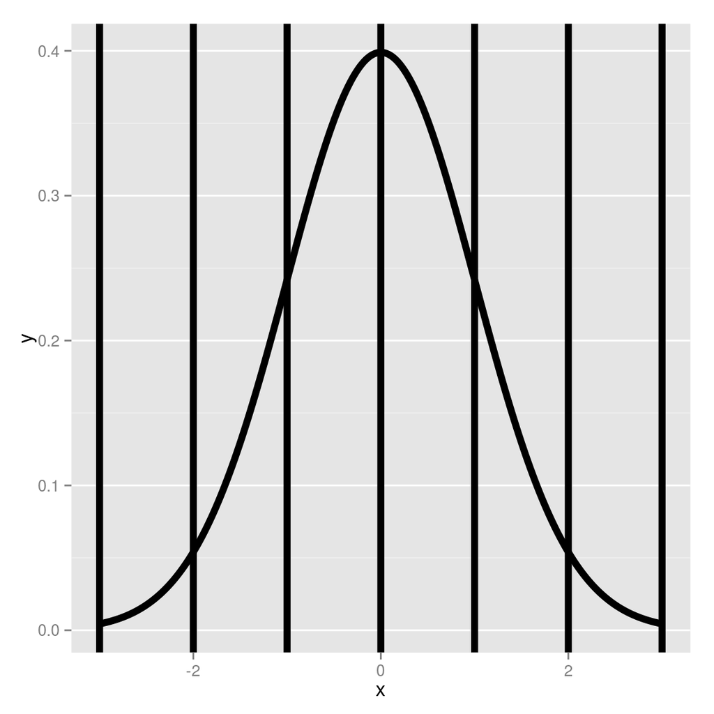

## Facts about the normal density

If $X \sim \mbox{N}(\mu,\sigma^2)$ then $Z = \frac{X -\mu}{\sigma} \sim N(0, 1)$

If $Z$ is standard normal $X = \mu + \sigma Z \sim \mbox{N}(\mu, \sigma^2)$

## More facts about the normal density

1. Approximately $68\%$, $95\%$ and $99\%$ of the normal density lies within $1$, $2$ and $3$ standard deviations from the mean, respectively
2. $-1.28$, $-1.645$, $-1.96$ and $-2.33$ are the $10^{th}$, $5^{th}$, $2.5^{th}$ and $1^{st}$ percentiles of the standard normal distribution respectively
3. By symmetry, $1.28$, $1.645$, $1.96$ and $2.33$ are the $90^{th}$, $95^{th}$, $97.5^{th}$ and $99^{th}$ percentiles of the standard normal distribution respectively

## Question

- What is the $95^{th}$ percentile of a $N(\mu, \sigma^2)$ distribution?
- Quick answer in R `qnorm(.95, mean = mu, sd = sd)`
- Or, because you have the standard normal quantiles memorized and you know that 1.645 is the 95th percentile you know that the answer has to be $\mu + \sigma 1.645$
- (In general $\mu + \sigma z_0$ where $z_0$ is the appropriate standard normal quantile)

## Question

- What is the probability that a $\mbox{N}(\mu,\sigma^2)$ RV is larger than $x$?

## Example

Assume that the number of daily ad clicks for a company is (approximately) normally distributed with a mean of 1020 and a standard deviation of 50. What’s the probability of getting more than 1,160 clicks in a day?

It’s not very likely, 1,160 is 2.8 standard deviations from the mean

```r
pnorm(1160, mean = 1020, sd = 50, lower.tail = FALSE)
```

```
## [1] 0.00255513
```

```r
pnorm(2.8, lower.tail = FALSE)
```

```
## [1] 0.00255513
```

```r
# Joe | 17 Oct, 2015
x <- 1160
mu <- 1020
sd <- 50

# x expressed ito standard deviations (xSd)
xSd <- (x - mu)/sd; xSd
```

```
## [1] 2.8
```

```r
pnorm(xSd, lower.tail = FALSE)
```

```
## [1] 0.00255513
```

## Example

Assume that the number of daily ad clicks for a company is (approximately) normally distributed with a mean of 1020 and a standard deviation of 50. What number of daily ad clicks would represent the one where 75% of days have fewer clicks (assuming days are independent and identically distributed)?

## Example

Assume that the number of daily ad clicks for a company is (approximately) normally distributed with a mean of 1020 and a standard deviation of 50. What number of daily ad clicks would represent the one where 75% of days have fewer clicks (assuming days are independent and identically distributed)?

```r
qnorm(0.75, mean = 1020, sd = 50)
```

```
## [1] 1053.724
```

## The Poisson distribution

- Used to model counts
- The Poisson mass function is $P(X = x; \lambda) = \frac{\lambda^x e^{-\lambda}}{x!}$ for $x=0,1,\ldots$
- The mean of this distribution is $\lambda$
- The variance of this distribution is $\lambda$
- Notice that $x$ ranges from $0$ to $\infty$

## Some uses for the Poisson distribution

- Modeling count data
- Modeling event-time or survival data
- Modeling contingency tables
- Approximating binomials when $n$ is large and $p$ is small

## Rates and Poisson random variables

- Poisson random variables are used to model rates
- $X \sim Poisson(\lambda t)$ where
- $\lambda = E[X / t]$ is the expected count per unit of time
- $t$ is the total monitoring time

## Example

The number of people that show up at a bus stop is Poisson with a mean of $2.5$ per hour.

If watching the bus stop for 4 hours, what is the probability that $3$ or fewer people show up for the whole time?

```r
ppois(3, lambda = 2.5 * 4)
```

```
## [1] 0.01033605
```

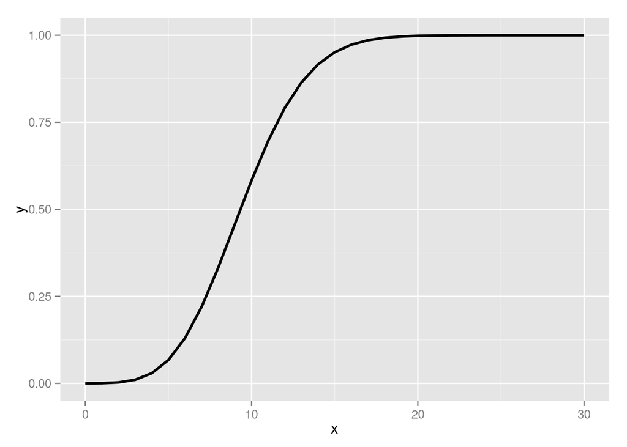

```r
# Joe | 17 Oct, 2015
library(ggplot2)

# Number of people showing up
xvals <- seq(0, 30, by = 1)
dat <- data.frame(
    x = xvals,
    y = ppois(xvals, lambda = 2.5 * 4),
    pmf = dpois(xvals, lambda = 2.5 * 4)
)
ggplot(dat, aes(x = x, y = y)) + geom_line(size = 1)
```

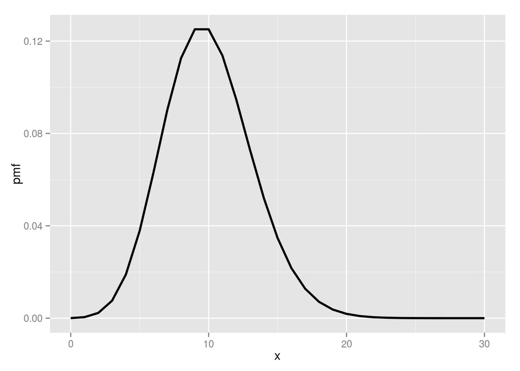

```r
ggplot(dat, aes(x = x, y = pmf)) + geom_line(size = 1)
```

## Poisson approximation to the binomial

- When $n$ is large and $p$ is small the Poisson distribution is an accurate approximation to the binomial distribution
- Notation
- $X \sim \mbox{Binomial}(n, p)$
- $\lambda = n p$
- $n$ gets large
- $p$ gets small

## Example, Poisson approximation to the binomial

We flip a coin with success probablity $0.01$ five hundred times.

What’s the probability of 2 or fewer successes?

```r
pbinom(2, size = 500, prob = .01)
```

```
## [1] 0.1233858
```

```r
ppois(2, lambda=500 * .01)
```

```
## [1] 0.124652
```